# IODS course project

Alexey Afonin

# Introduction to Open Data Science - Course Project

# About the project

## A short description and a link to the githuib repository

This is a course that should help me to better work with data analysis in the future. I already *love* **markdown** *:)*. I have R knowledge, but I never completed a course in the language, so sometimes I find I am doing very simple things the hardest way imaginable. I hope this course will close these gaps in my knowledge.

The crash course is nice, as I’m not that used to the tidyverse syntax, and was taught to use base R (subsets, slices and such). I use git for my work, so it’s not very convenient for me to start using PATs. But i checked, and it indeed works. I just prefer to do it through gpg.

Here’s the link to the repository  
[link to the github repository](https://github.com/crastr/IODS-project)

```r
# This is a so-called "R chunk" where you can write R code.
date()
```

```
## [1] "Tue Nov 21 08:55:41 2023"
```

The text continues here.

# 2: Regression and model validation

*Describe the work you have done this week and summarize your learning.*

## 2.1 Data wrangling.

After understanding the metadata file and skipping the Finnish language instructions that were unnecessary it was easy to prepare a data file [this data file](https://github.com/crastr/IODS-project/blob/master/data/learning2014.txt). The script can be found [here](https://github.com/crastr/IODS-project/blob/master/data/create_learning2020.R).I used plyr and tiidyverse to do the conversions of the raw data into a workable file.

## 2.2 Analysis

The dataset is the result of a survey on teaching and learning that was conducted as a research project in 2014. The dataset was loaded in the next chunk and the dimensions and structure of the document are output.

```r
library(tidyverse)
library(GGally)
learning2014_csv <- read_csv("/home/alex/ods_course/IODS-project_R/data/learning2014_AA.csv")
dim(learning2014_csv)
```

```
## [1] 166   7
```

```r
str(learning2014_csv)
```

```
## spc_tbl_ [166 × 7] (S3: spec_tbl_df/tbl_df/tbl/data.frame)
##  $ gender  : chr [1:166] "F" "M" "F" "M" ...
##  $ age     : num [1:166] 53 55 49 53 49 38 50 37 37 42 ...
##  $ attitude: num [1:166] 3.7 3.1 2.5 3.5 3.7 3.8 3.5 2.9 3.8 2.1 ...
##  $ deep    : num [1:166] 3.58 2.92 3.5 3.5 3.67 ...
##  $ stra    : num [1:166] 3.38 2.75 3.62 3.12 3.62 ...
##  $ surf    : num [1:166] 2.58 3.17 2.25 2.25 2.83 ...
##  $ points  : num [1:166] 25 12 24 10 22 21 21 31 24 26 ...
##  - attr(*, "spec")=
##   .. cols(
##   ..   gender = col_character(),
##   ..   age = col_double(),
##   ..   attitude = col_double(),
##   ..   deep = col_double(),
##   ..   stra = col_double(),
##   ..   surf = col_double(),
##   ..   points = col_double()
##   .. )
##  - attr(*, "problems")=<externalptr>
```

The data.frame contains 166 lines and 7 columns. The first column encodes gender, and has the character type. The rest are all numeric, and contain the data which will be used for the regression analysis. The *“attitude”*, *“deep”*, *“stra”*, and *“surf”* columns contain the combinations of results from the original dataframe. The full metadata explanation can be found [here](https://github.com/crastr/IODS-project/blob/master/data/JYTOPKYS2-meta.txt). The explanation for the study can be found [here](http://www.slideshare.net/kimmovehkalahti/the-relationship-between-learning-approaches-and-students-achievements-in-an-introductory-statistics-course-in-finland).

Briefly:

- *attitude* variable is *Global attitude toward statistics* composite score of the questions having to do with global attitude toward statistics
- *deep* variable is *Deep approach* adjusted composite score of the questions connected with deep understanding of statistics
- *stra* variable is *Strategic approach* adjusted composite score of the questions connected with how strategically the participant approaches the subject
- *surf* variable is *Surface approach* adjusted composite score of the questions connected with how whether the participant can understand the material deeply and whther the participants has problems studying.

### 2.2.2 Data exploration

#### 2.2.2.1 Summary for the variables

```r
summaries <- learning2014_csv %>%
  summarise(across(where(is.numeric), list(mean = ~mean(.), sd = ~sd(.), min = ~min(.), max = ~max(.), median = ~median(.))))

print(t(summaries))
```

```
##                       [,1]
## age_mean        25.5120482
## age_sd           7.7660785
## age_min         17.0000000
## age_max         55.0000000
## age_median      22.0000000
## attitude_mean    3.1427711
## attitude_sd      0.7299079
## attitude_min     1.4000000
## attitude_max     5.0000000
## attitude_median  3.2000000
## deep_mean        3.6797189
## deep_sd          0.5541369
## deep_min         1.5833333
## deep_max         4.9166667
## deep_median      3.6666667
## stra_mean        3.1212349
## stra_sd          0.7718318
## stra_min         1.2500000
## stra_max         5.0000000
## stra_median      3.1875000
## surf_mean        2.7871486
## surf_sd          0.5288405
## surf_min         1.5833333
## surf_max         4.3333333
## surf_median      2.8333333
## points_mean     22.7168675
## points_sd        5.8948836
## points_min       7.0000000
## points_max      33.0000000
## points_median   23.0000000
```

#### 2.2.2.2 Graphical data summary

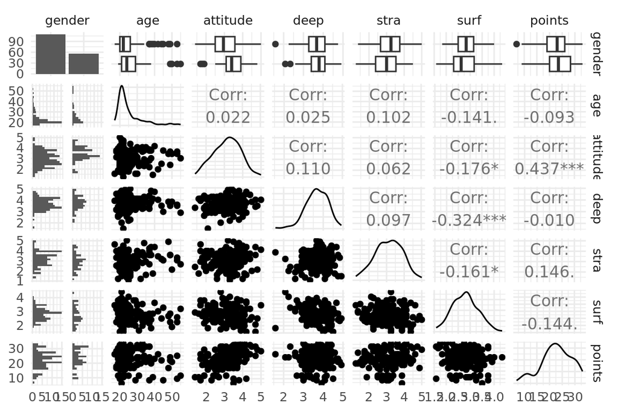

```r
ggpairs(learning2014_csv, mapping = aes(), lower = list(combo = wrap("facethist", bins = 20))) + theme_minimal()
```

**Description**

1. The gender distribution is uneven
2. The age Is also skewed to younger participants, with few only a older participants in each gender
3. No other variable has a stark clustering behaviour
4. There are significant correlations between variables
   - **Negative**:
     - surf/deep - these are expected to be inversely correlated, as are surf/attitude and surf/strategy
     - age/surf appear to be negatively correlated, but the p-value is between 0.5 and 0.1, as it is for surf/points.
   - **Positive**:
     - attitude/points, stra/points

These results make sense at the first glance.

### 2.2.3 Linear regression

I have chosen the three variables to check: attitude, age and surf

```r
linear_modelling_for_learning2014_csv  <- lm(points ~ surf + attitude + age, data = learning2014_csv)
summary(linear_modelling_for_learning2014_csv)
```

```
##
## Call:
## lm(formula = points ~ surf + attitude + age, data = learning2014_csv)
##
## Residuals:
##     Min      1Q  Median      3Q     Max
## -17.973  -3.430   0.167   3.997  10.444
##
## Coefficients:
##             Estimate Std. Error t value Pr(>|t|)
## (Intercept) 16.85628    3.53786   4.765 4.18e-06 ***
## surf        -0.96049    0.79943  -1.201    0.231
## attitude     3.42388    0.57353   5.970 1.45e-08 ***
## age         -0.08713    0.05361  -1.625    0.106
## ---
## Signif. codes:  0 '***' 0.001 '**' 0.01 '*' 0.05 '.' 0.1 ' ' 1
##
## Residual standard error: 5.294 on 162 degrees of freedom
## Multiple R-squared:  0.2082, Adjusted R-squared:  0.1935
## F-statistic:  14.2 on 3 and 162 DF,  p-value: 2.921e-08
```

Only one explanatory variable showed statistically significant connection to the points outcome, thus only attitude variable will be kept for the next modelling step.

```r
linear_modelling_for_learning2014_csv_pruned  <-lm(points ~ attitude, data = learning2014_csv)
summary(linear_modelling_for_learning2014_csv_pruned)
```

```
##
## Call:
## lm(formula = points ~ attitude, data = learning2014_csv)
##
## Residuals:
##      Min       1Q   Median       3Q      Max
## -16.9763  -3.2119   0.4339   4.1534  10.6645
##
## Coefficients:
##             Estimate Std. Error t value Pr(>|t|)
## (Intercept)  11.6372     1.8303   6.358 1.95e-09 ***
## attitude      3.5255     0.5674   6.214 4.12e-09 ***
## ---
## Signif. codes:  0 '***' 0.001 '**' 0.01 '*' 0.05 '.' 0.1 ' ' 1
##
## Residual standard error: 5.32 on 164 degrees of freedom
## Multiple R-squared:  0.1906, Adjusted R-squared:  0.1856
## F-statistic: 38.61 on 1 and 164 DF,  p-value: 4.119e-09
```

### 2.2.3.1 Linear model diagnositic plots

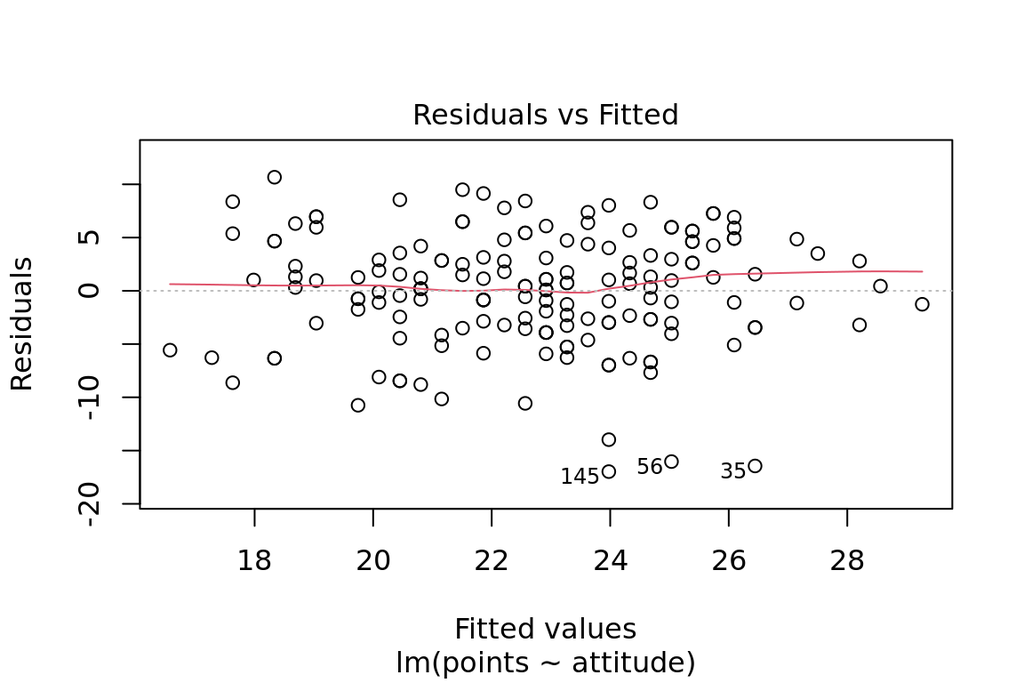

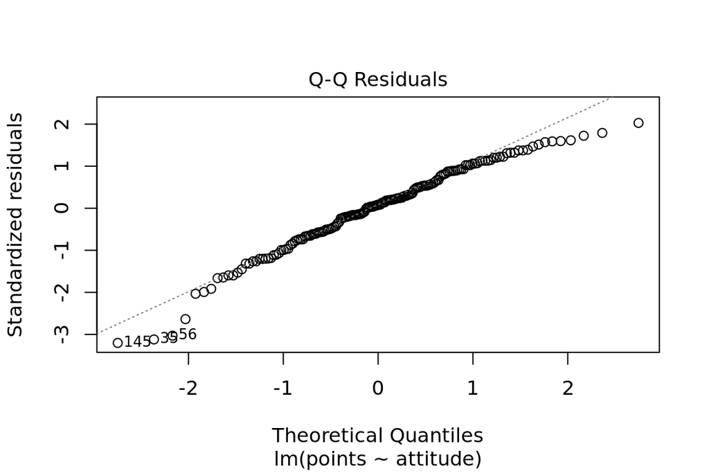

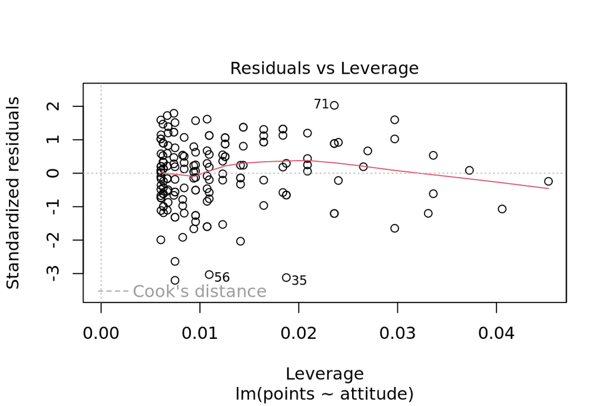

```r
plot(linear_modelling_for_learning2014_csv_pruned, which=c(1,2,5))
```

Using these plots we can investigate the assumptions of the model.

1. We can use the “Residuals vs fitted” plots to investigate the constant variance assumption. If the variance is constant, we should expect to see point distributed without noticeable structure i.e. randomly. This is more or less what we see in our data. Although the points around 28 on the x axis seem to be bunched up, this may also be the result of low n-numbers, so we can assume constant variance.
2. The q-q recapitulates plot can be used to identify whether the “normal distribution of residuals” is met. The middle part of the plot follows the 45 degree line, meaning that the distribution is close to normal for the bulk of the data. The tails of the plot do deviate form the line, meaning that there is a deviation form the perfect normality. At the bottom left there are 3 points that can be considered outliers. Further investigation is needed to determine whether these point should not be included into furhter analysis.
3. The residuals vs Leverage plot shows whitewater the data contains influential outliers. Three points are highlighted: 71, 56 and 35. These should be investigated to determine if the data is fine, for example there can be a data entry mistake, missing value problem, or a true outlier. The points 56 and 35 are present on both the q-q and the residuals vs leverage plots, so the next step would be checking the data to see what happened to these points.

# 3: Logistic regression

#### Necessary packages

```r
if (!require(tidyverse) == T) {
  install.packages("tidyverse")
}
library(tidyverse)


if (!require(gt) == T) {
  install.packages("gt")
}
library(gt)
```

## 3.1 Data wrangling

The dataframes were merged a modified according to the instructions. The resulting dataframe contains 370 observations with 35 columns. The r-script used is [here](https://github.com/crastr/IODS-project/blob/master/data/create_alc.R).

## 3.2 Read the file and describe the data a bit

```r
aa_alc <- read_csv("/home/alex/ods_course/IODS-project_R/data/aa_alc.csv")
str(aa_alc)
```

```
## spc_tbl_ [370 × 35] (S3: spec_tbl_df/tbl_df/tbl/data.frame)
##  $ school     : chr [1:370] "GP" "GP" "GP" "GP" ...
##  $ sex        : chr [1:370] "F" "F" "F" "F" ...
##  $ age        : num [1:370] 18 17 15 15 16 16 16 17 15 15 ...
##  $ address    : chr [1:370] "U" "U" "U" "U" ...
##  $ famsize    : chr [1:370] "GT3" "GT3" "LE3" "GT3" ...
##  $ Pstatus    : chr [1:370] "A" "T" "T" "T" ...
##  $ Medu       : num [1:370] 4 1 1 4 3 4 2 4 3 3 ...
##  $ Fedu       : num [1:370] 4 1 1 2 3 3 2 4 2 4 ...
##  $ Mjob       : chr [1:370] "at_home" "at_home" "at_home" "health" ...
##  $ Fjob       : chr [1:370] "teacher" "other" "other" "services" ...
##  $ reason     : chr [1:370] "course" "course" "other" "home" ...
##  $ guardian   : chr [1:370] "mother" "father" "mother" "mother" ...
##  $ traveltime : num [1:370] 2 1 1 1 1 1 1 2 1 1 ...
##  $ studytime  : num [1:370] 2 2 2 3 2 2 2 2 2 2 ...
##  $ schoolsup  : chr [1:370] "yes" "no" "yes" "no" ...
##  $ famsup     : chr [1:370] "no" "yes" "no" "yes" ...
##  $ activities : chr [1:370] "no" "no" "no" "yes" ...
##  $ nursery    : chr [1:370] "yes" "no" "yes" "yes" ...
##  $ higher     : chr [1:370] "yes" "yes" "yes" "yes" ...
##  $ internet   : chr [1:370] "no" "yes" "yes" "yes" ...
##  $ romantic   : chr [1:370] "no" "no" "no" "yes" ...
##  $ famrel     : num [1:370] 4 5 4 3 4 5 4 4 4 5 ...
##  $ freetime   : num [1:370] 3 3 3 2 3 4 4 1 2 5 ...
##  $ goout      : num [1:370] 4 3 2 2 2 2 4 4 2 1 ...
##  $ Dalc       : num [1:370] 1 1 2 1 1 1 1 1 1 1 ...
##  $ Walc       : num [1:370] 1 1 3 1 2 2 1 1 1 1 ...
##  $ health     : num [1:370] 3 3 3 5 5 5 3 1 1 5 ...
##  $ failures   : num [1:370] 0 0 2 0 0 0 0 0 0 0 ...
##  $ paid       : chr [1:370] "no" "no" "yes" "yes" ...
##  $ absences   : num [1:370] 5 3 8 1 2 8 0 4 0 0 ...
##  $ G1         : num [1:370] 2 7 10 14 8 14 12 8 16 13 ...
##  $ G2         : num [1:370] 8 8 10 14 12 14 12 9 17 14 ...
##  $ G3         : num [1:370] 8 8 11 14 12 14 12 10 18 14 ...
##  $ average_alc: num [1:370] 1 1 2.5 1 1.5 1.5 1 1 1 1 ...
##  $ high_use   : logi [1:370] FALSE FALSE TRUE FALSE FALSE FALSE ...
##  - attr(*, "spec")=
##   .. cols(
##   ..   school = col_character(),
##   ..   sex = col_character(),
```

[output cut: 20 more lines]

```
##   ..   freetime = col_double(),
##   ..   goout = col_double(),
##   ..   Dalc = col_double(),
##   ..   Walc = col_double(),
##   ..   health = col_double(),
##   ..   failures = col_double(),
##   ..   paid = col_character(),
##   ..   absences = col_double(),
##   ..   G1 = col_double(),
##   ..   G2 = col_double(),
##   ..   G3 = col_double(),
##   ..   average_alc = col_double(),
##   ..   high_use = col_logical()
##   .. )
##  - attr(*, "problems")=<externalptr>
```

```r
colnames(aa_alc)
```

```
##  [1] "school"      "sex"         "age"         "address"     "famsize"
##  [6] "Pstatus"     "Medu"        "Fedu"        "Mjob"        "Fjob"
## [11] "reason"      "guardian"    "traveltime"  "studytime"   "schoolsup"
## [16] "famsup"      "activities"  "nursery"     "higher"      "internet"
## [21] "romantic"    "famrel"      "freetime"    "goout"       "Dalc"
## [26] "Walc"        "health"      "failures"    "paid"        "absences"
## [31] "G1"          "G2"          "G3"          "average_alc" "high_use"
```

The data show student achievement in secondary education of two Portuguese schools, the data contains 370 observations of 35 variables . The data attributes include student grades, demographic, social and school related features) and it was collected by using school reports and questionnaires. The different features can be used to analyse the dataset and make predictions. A more detailed information can be found [here](http://www.archive.ics.uci.edu/dataset/320/student+performance)

1. **“school”**: The name or type of school the student attends.
2. **“sex”**: The student’s gender.
3. **“age”**: The student’s age.
4. **“address”**: The student’s home address or type of locality (urban/rural).
5. **“famsize”**: The size of the student’s family.
6. **“Pstatus”**: The marital status of the student’s parents.
7. **“Medu”**: The mother’s education level.
8. **“Fedu”**: The father’s education level.
9. **“Mjob”**: The mother’s job.
10. **“Fjob”**: The father’s job.
11. **“reason”**: The reason for choosing this school.
12. **“guardian”**: The student’s primary guardian.
13. **“traveltime”**: Time taken to travel to school.
14. **“studytime”**: Time spent on studying outside of school.
15. **“schoolsup”**: Whether the student receives school support.
16. **“famsup”**: Whether the student receives family support.
17. **“activities”**: Participation in extracurricular activities.
18. **“nursery”**: Whether the student attended nursery school.
19. **“higher”**: Aspirations for higher education.
20. **“internet”**: Access to the internet at home.
21. **“romantic”**: Involvement in a romantic relationship.
22. **“famrel”**: Quality of family relationships.
23. **“freetime”**: Amount of free time after school.
24. **“goout”**: Frequency of going out with friends.
25. **“Dalc”**: Daily alcohol consumption.
26. **“Walc”**: Weekly alcohol consumption.
27. **“health”**: General health status.
28. **“failures”**: Number of past class failures.
29. **“paid”**: Whether the student is enrolled in extra paid classes.
30. **“absences”**: Number of school absences.
31. **“G1”**: Grade in the first period.
32. **“G2”**: Grade in the second period.
33. **“G3”**: Final grade.
34. **“average_alc”**: Average alcohol consumption (perhaps a computed variable from Dalc and Walc).
35. **“high_use”**: Indicator of high alcohol use (likely a derived variable).

### 3.3 Choosing the variable

I decided to look at **“failures”**, **“absences”**, **“freetime”** and **“famrel”**. I would expect that:

1. The failures might be positively associated with the higher consumption
2. The abscences might also be positively associated with the higher consumption
3. The freetime may be associated with weekly consuption, but It is possible that the association will be inverse.
4. The family relations may be inversely correlated.

### 3.4 Testing the assumptions:

```r
summaries <- aa_alc %>% group_by(high_use) %>% select(.,c("failures", "absences", "freetime", "famrel","high_use")) %>%
  summarise(across(where(is.numeric), list(Average = ~mean(.), sd = ~sd(.))))
```

```r
gt(summaries) %>% cols_align("left") %>% opt_stylize(color="gray", style=3)  %>% tab_header("Table for chosen variables")
```

Table for chosen variables

| high_use | failures_Average | failures_sd | absences_Average | absences_sd | freetime_Average | freetime_sd | famrel_Average | famrel_sd |
| --- | --- | --- | --- | --- | --- | --- | --- | --- |
| FALSE | 0.1196911 | 0.4370868 | 3.710425 | 4.464017 | 3.119691 | 0.9869096 | 4.007722 | 0.8935266 |
| TRUE | 0.3513514 | 0.7464906 | 6.378378 | 7.060845 | 3.468468 | 0.9421428 | 3.765766 | 0.9337603 |

These are the averages and standard deviation values for all the variables, to better see which variables are interesting to look at closer.

First looking at overall structure, whehther there is something to connect the chosen variables.

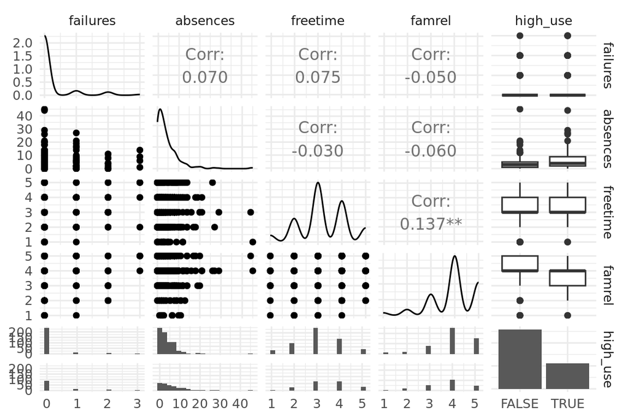

```r
ggpairs(select(aa_alc,c("failures", "absences", "freetime", "famrel","high_use")), mapping = aes(), lower = list(combo = wrap("facethist", bins = 20))) + theme_minimal()
```

#### Failures

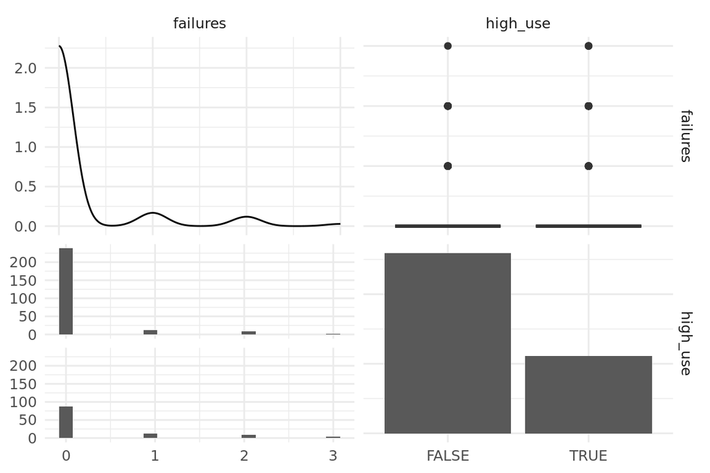

```r
ggpairs(select(aa_alc,c("failures","high_use")), mapping = aes(), lower = list(combo = wrap("facethist", bins = 20))) + theme_minimal()
```

The number of failures is slightly higher in the high consumption group, but not bu much. The overwhelming majority of participants in each case have 0 falures. This was expected..

#### Abscences

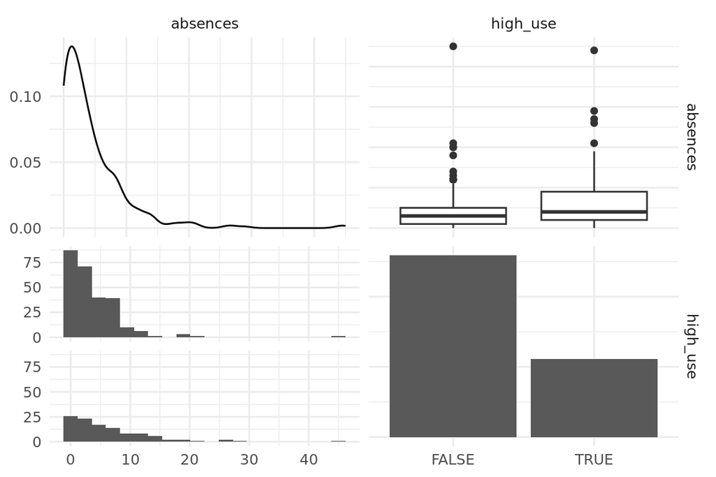

```r
ggpairs(select(aa_alc,c("absences","high_use")), mapping = aes(), lower = list(combo = wrap("facethist", bins = 20))) + theme_minimal()
```

The number of absences in the high use groups is higher, as expected. The standard deviation is also much higher in this group, suggesting more variability in the absences.

#### Freetime

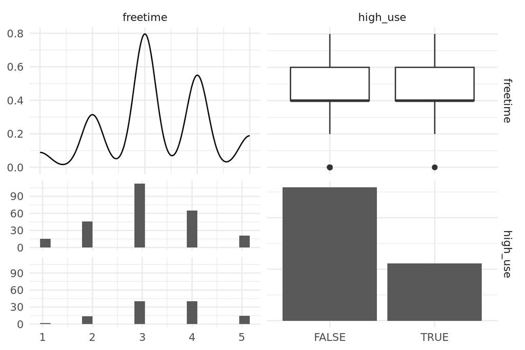

```r
ggpairs(select(aa_alc,c("freetime","high_use")), mapping = aes(), lower = list(combo = wrap("facethist", bins = 20))) + theme_minimal()
```

The freetime variable has different mean and very similar sd, the high consumption group has a slightly higher average. I was interested in the relation, and the results are interesting.

#### Family relation

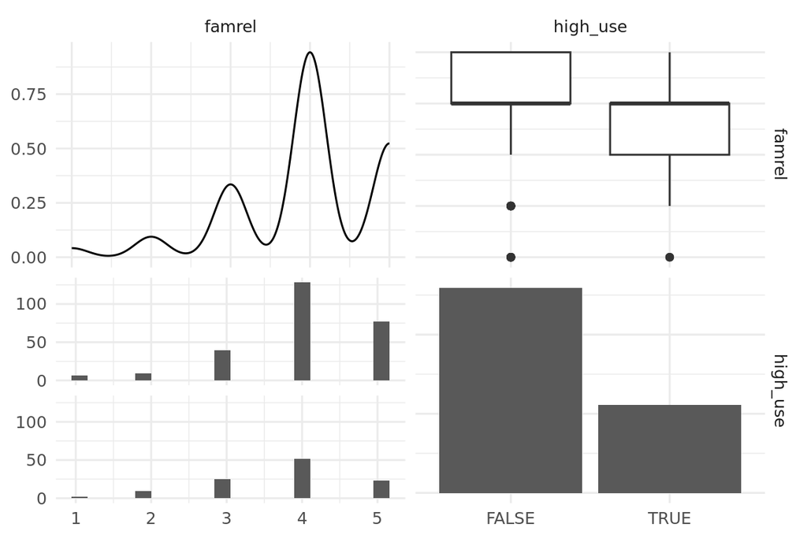

```r
ggpairs(select(aa_alc,c("famrel","high_use")), mapping = aes(), lower = list(combo = wrap("facethist", bins = 20))) + theme_minimal()
```

The family relation variable seems to be lower in the high consumption group, as expected.

### 3.5 Using logistic regression

```r
first_log_regression <- glm(high_use ~ failures + absences + freetime + famrel, data = aa_alc, family = "binomial")

# create model summary and extract the coeffs
summary(first_log_regression)
```

```
##
## Call:
## glm(formula = high_use ~ failures + absences + freetime + famrel,
##     family = "binomial", data = aa_alc)
##
## Coefficients:
##             Estimate Std. Error z value Pr(>|z|)
## (Intercept) -1.55560    0.63703  -2.442 0.014608 *
## failures     0.58297    0.20259   2.878 0.004007 **
## absences     0.08375    0.02230   3.755 0.000173 ***
## freetime     0.43091    0.12804   3.365 0.000764 ***
## famrel      -0.31981    0.13098  -2.442 0.014622 *
## ---
## Signif. codes:  0 '***' 0.001 '**' 0.01 '*' 0.05 '.' 0.1 ' ' 1
##
## (Dispersion parameter for binomial family taken to be 1)
##
##     Null deviance: 452.04  on 369  degrees of freedom
## Residual deviance: 408.17  on 365  degrees of freedom
## AIC: 418.17
##
## Number of Fisher Scoring iterations: 4
```

From the model we can see the following:

- The higher values of **failures absences** and the **freetime** predictors are associated with a higher likelihood of *high_use* being *TRUE*, for **family relations** the opposite is true.
- All predictors appear to be statistically significant, as indicated by their p-values and significance codes
- The reduction in deviance from null to residual suggests the model with predictors fits better than the null model.
- The reduction in deviance from null to residual suggests the model with predictors fits better than the null model - the one without ony predictor variables.

```r
coeffs <- summary(first_log_regression) %>% coefficients()
coeffs
```

```
##                Estimate Std. Error   z value     Pr(>|z|)
## (Intercept) -1.55560199 0.63703172 -2.441954 0.0146080178
## failures     0.58296988 0.20258843  2.877607 0.0040070412
## absences     0.08375499 0.02230317  3.755295 0.0001731376
## freetime     0.43090906 0.12804024  3.365419 0.0007642749
## famrel      -0.31981102 0.13098388 -2.441606 0.0146221015
```

```r
OddsRatio <- exp(coeffs)
confidence <- confint(first_log_regression)
result <- cbind(OddsRatio, confidence)
result
```

```
##              Estimate Std. Error     z value Pr(>|z|)      2.5 %      97.5 %
## (Intercept) 0.2110623   1.890860  0.08699073 1.014715 -2.8317664 -0.32620631
## failures    1.7913506   1.224568 17.77169287 1.004015  0.1917587  0.99258448
## absences    1.0873624   1.022554 42.74681512 1.000173  0.0420769  0.13014453
## freetime    1.5386556   1.136599 28.94562433 1.000765  0.1840339  0.68715409
## famrel      0.7262863   1.139949  0.08702100 1.014730 -0.5789180 -0.06341917
```

Here we can see the same, the first three predictors have positive association with consumption, the **family relation** variable has a negative association. We can see that the strongest connection is with failures, then **freetime** and **famrel**, while the link to **absences** is low.

It is important to keep in mind that this is logistical regression, not the previosuly investigated linear regression. Tha means that the estimate in this table represents the “odds ratos” and be thought of in terms of likelihood. It means, that for examples in our case the increase in **failures** by one unit increases the likelihood of high alcohol consumption by 1.8.

The results are in agreement with the hypotheses I started with. Interestingly there seems to be a connection between the free time and the consumption levels, which were not obvious when just looking at the data.

### 3.6 Exploring the predictive power

We can use test the predictive of the model that we created earlier to see if it can be used to actually predict the alcohol consumption based on the the four chosen variables. We can predict for each student the probability of increased consumption.

```r
aa_alc$predicted_probabilities <- predict(first_log_regression, type = "response")

aa_alc <- mutate(aa_alc,prediction  = predicted_probabilities > 0.5)

table(Actual = aa_alc$high_use, Predicted = aa_alc$prediction)
```

```
##        Predicted
## Actual  FALSE TRUE
##   FALSE   236   23
##   TRUE     85   26
```

These are the 2x2 cross tabulation count results.

```r
((table(Actual_percentage = aa_alc$high_use, Predicted_percentage = aa_alc$prediction))/length(aa_alc$prediction)) * 100
```

```
##                  Predicted_percentage
## Actual_percentage     FALSE      TRUE
##             FALSE 63.783784  6.216216
##             TRUE  22.972973  7.027027
```

The False outcome was correctly predicted for 236 participants (63%), True was predicted for 26 (7%).

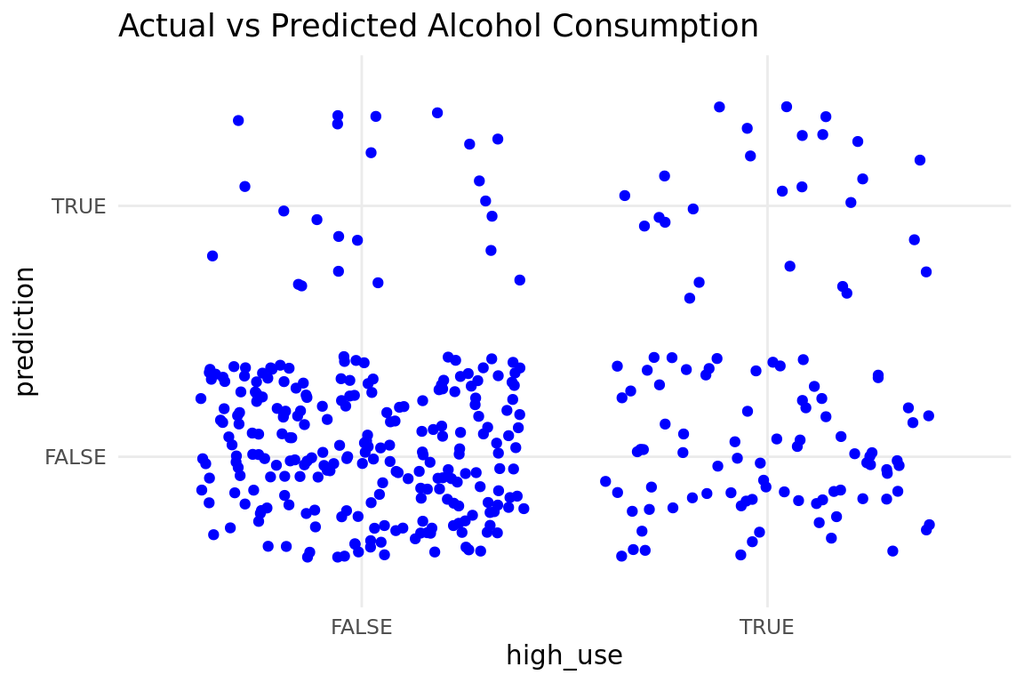

```r
library(ggplot2)
ggplot(aa_alc, aes(x=high_use, y=prediction)) +
  geom_jitter(color="blue") +
  theme_minimal() +
  labs(title="Actual vs Predicted Alcohol Consumption")
```

```r
confusion_matrix <- table(Predicted = aa_alc$prediction,Actual = aa_alc$high_use)
training_error <- 1 - sum(diag(confusion_matrix)) / sum(confusion_matrix)
training_error
```

```
## [1] 0.2918919
```

The total training error was 29%

##### 3.6.2 Comparing to simple guessing strategy

We can compare our model to a simple guessing strategy - always predicting the most common class

First we determine which is the bigger group:

```r
sum(aa_alc$high_use)/length(aa_alc$high_use)
```

```
## [1] 0.3
```

There are 30% of higher consuming participants, so the more prevalent group is low consuming.

```r
simple_guess_accuracy <- mean(aa_alc$high_use == F)
model_accuracy <- mean(aa_alc$high_use == aa_alc$prediction)
```

```r
simple_guess_accuracy
```

```
## [1] 0.7
```

```r
model_accuracy
```

```
## [1] 0.7081081
```

The accuracy of the model is marginally better than guessing.

#### 3.7 Cross-validating the model

We can preform a cross-validation of the model, meaning that we will test the model performance on subset of the same data fo determine how accurately the chosen model can work in practice. For that we will be using the `cv.glm` function from the boot library. The idea is to test how well the model predicts the status using the ten different subset subsets fo the data in sequence.

```r
loss_func <- function(class, prob) {
  n_wrong <- abs(class - prob) > 0.5
  mean(n_wrong)
}
library(boot)

cv <- cv.glm(data = aa_alc, cost = loss_func, glmfit = first_log_regression, K = 10)

cv$delta[1]
```

```
## [1] 0.2918919
```

#### 3.8

We can try to use all the predictors to see how the number of predictors influences the model parameters. For this we exclude all the predictors that were used to create the outcome variable

First we load additional lobraries

```r
if (!require(caret) == T) {
  install.packages("caret")
}
library(caret)

if (!require(glmnet) == T) {
  install.packages("glmnet")
}
library(glmnet)
```

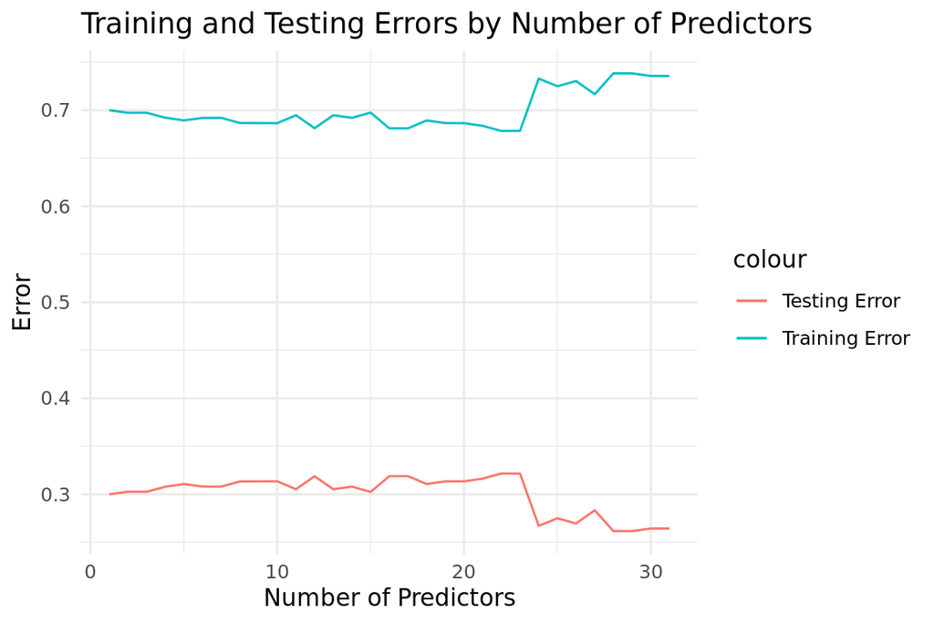

```r
predictors <- setdiff(colnames(aa_alc), c("Dalc","Walc","average_alc","high_use","predicted_probabilities","prediction" ))
# Initialize vectors to store errors
training_errors <- c()
testing_errors <- c()
number_of_predictors <- c()
model_summaries <- list()

aa_alc$high_use <- as.factor(aa_alc$high_use)

# Loop over models with decreasing number of predictors
for (i in length(predictors):1) {
    # Select a subset of predictors
    current_predictors <- predictors[1:i]
    formula <- as.formula(paste("high_use ~", paste(current_predictors, collapse = "+")))
    set.seed(123)  # for reproducibility
    fitControl <- trainControl(method = "cv", number = 10)  # 10-fold cross-validation
    model <- train(formula, data = aa_alc, method = "glm", family = "binomial", trControl = fitControl)

    # Store training and testing errors
    training_errors <- c(training_errors, mean(model$results$Accuracy))
    testing_errors <- c(testing_errors, 1 - max(model$results$Accuracy))# Replace 'Accuracy' with the appropriate metric
    number_of_predictors <- c(number_of_predictors, i)
    model_summaries[[i]] <- model$coefnames
}

results_df <- data.frame(
    Number_of_Predictors = number_of_predictors,
    Training_Error = training_errors,
    Testing_Error = testing_errors
)

# Plotting
ggplot(results_df, aes(x = Number_of_Predictors)) +
    geom_line(aes(y = Training_Error, colour = "Training Error")) +
    geom_line(aes(y = Testing_Error, colour = "Testing Error")) +
    labs(title = "Training and Testing Errors by Number of Predictors",
         x = "Number of Predictors",
         y = "Error") +
    theme_minimal()
```

```r
setdiff(model_summaries[[26]],model_summaries[[25]])
```

```
## [1] "failures"
```

As we know, the **failures** was a great predictor. So to check how the plot looks if we start with the better predictors I reversed the `predictors` vector.

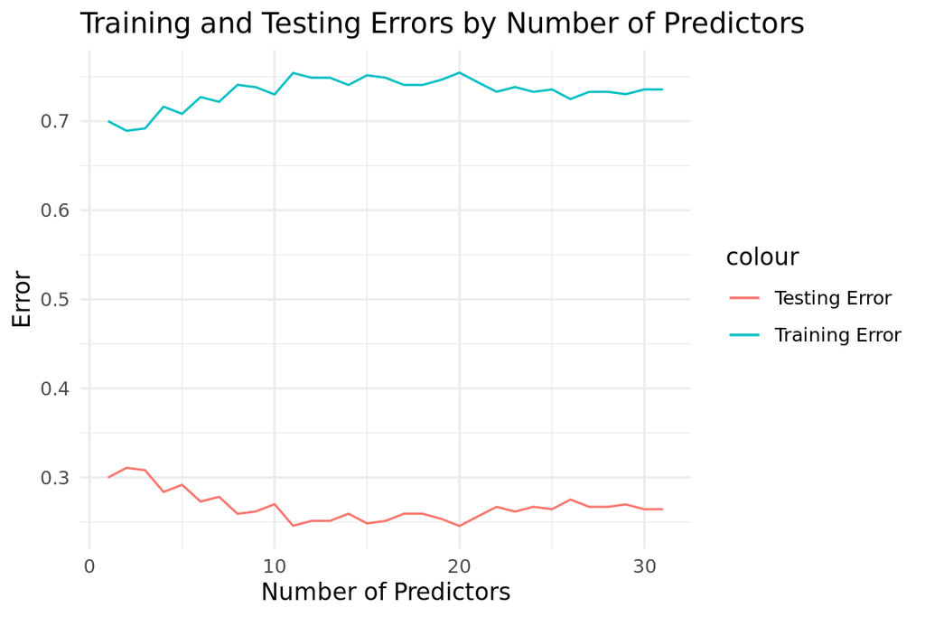

```r
predictors  <- rev(predictors)
# Initialize vectors to store errors
training_errors <- c()
testing_errors <- c()
number_of_predictors <- c()
model_summaries <- list()

# Loop over models with decreasing number of predictors
for (i in length(predictors):1) {
    # Select a subset of predictors
    current_predictors <- predictors[1:i]
    formula <- as.formula(paste("high_use ~", paste(current_predictors, collapse = "+")))
    set.seed(123)  # for reproducibility
    fitControl <- trainControl(method = "cv", number = 10)  # 10-fold cross-validation
    model <- train(formula, data = aa_alc, method = "glm", family = "binomial", trControl = fitControl)

    # Store training and testing errors
    training_errors <- c(training_errors, mean(model$results$Accuracy))
    testing_errors <- c(testing_errors, 1 - max(model$results$Accuracy))# Replace 'Accuracy' with the appropriate metric
    number_of_predictors <- c(number_of_predictors, i)
    model_summaries[[i]] <- model$coefnames
}

results_df <- data.frame(
    Number_of_Predictors = number_of_predictors,
    Training_Error = training_errors,
    Testing_Error = testing_errors
)

# Plotting
ggplot(results_df, aes(x = Number_of_Predictors)) +
    geom_line(aes(y = Training_Error, colour = "Training Error")) +
    geom_line(aes(y = Testing_Error, colour = "Testing Error")) +
    labs(title = "Training and Testing Errors by Number of Predictors",
         x = "Number of Predictors",
         y = "Error") +
    theme_minimal()
```

That makes the model better overall, with the minimum value being:

```
## [1] 0.2454599
```

With adding of the guardian variable.

```r
predictors[20]
```

```
## [1] "guardian"
```

# 4: Clustering and classification